# Risk Factor Analysis

## Outcome Variable

**Outcome Variable:** dead

## Predictor Variables

**Intervention Variable:** ever_co024

**Adjustment Set:**

- sex
- arm
- brthmon
- vagbrth
- hhwealth_quart
- W_mage
- W_mhtcm
- W_mwtkg
- W_mbmi
- W_meducyrs
- W_feducyrs
- W_nrooms
- W_parity
- impsan
- safeh20
- delta_vagbrth
- delta_hhwealth_quart
- delta_W_mage
- delta_W_mhtcm
- delta_W_mwtkg
- delta_W_mbmi
- delta_W_meducyrs
- delta_W_feducyrs
- delta_W_nrooms
- delta_W_parity
- delta_impsan
- delta_safeh20

## Stratifying Variables

The analysis was stratified on these variable(s):

- studyid
- country

## Data Summary

| studyid | country | ever_co024 | dead | n_cell | n | outcome_variable |
| --- | --- | --- | --- | --- | --- | --- |
| ki0047075b-MAL-ED | BANGLADESH | 0 | 0 | 222 | 263 | dead |
| ki0047075b-MAL-ED | BANGLADESH | 0 | 1 | 2 | 263 | dead |
| ki0047075b-MAL-ED | BANGLADESH | 1 | 0 | 39 | 263 | dead |
| ki0047075b-MAL-ED | BANGLADESH | 1 | 1 | 0 | 263 | dead |
| ki0047075b-MAL-ED | INDIA | 0 | 0 | 195 | 251 | dead |
| ki0047075b-MAL-ED | INDIA | 0 | 1 | 2 | 251 | dead |
| ki0047075b-MAL-ED | INDIA | 1 | 0 | 54 | 251 | dead |
| ki0047075b-MAL-ED | INDIA | 1 | 1 | 0 | 251 | dead |
| ki0047075b-MAL-ED | PERU | 0 | 0 | 288 | 302 | dead |
| ki0047075b-MAL-ED | PERU | 0 | 1 | 2 | 302 | dead |
| ki0047075b-MAL-ED | PERU | 1 | 0 | 12 | 302 | dead |
| ki0047075b-MAL-ED | PERU | 1 | 1 | 0 | 302 | dead |
| ki0047075b-MAL-ED | SOUTH AFRICA | 0 | 0 | 289 | 312 | dead |
| ki0047075b-MAL-ED | SOUTH AFRICA | 0 | 1 | 0 | 312 | dead |
| ki0047075b-MAL-ED | SOUTH AFRICA | 1 | 0 | 23 | 312 | dead |
| ki0047075b-MAL-ED | SOUTH AFRICA | 1 | 1 | 0 | 312 | dead |
| ki0047075b-MAL-ED | TANZANIA, UNITED REPUBLIC OF | 0 | 0 | 235 | 261 | dead |
| ki0047075b-MAL-ED | TANZANIA, UNITED REPUBLIC OF | 0 | 1 | 3 | 261 | dead |
| ki0047075b-MAL-ED | TANZANIA, UNITED REPUBLIC OF | 1 | 0 | 23 | 261 | dead |
| ki0047075b-MAL-ED | TANZANIA, UNITED REPUBLIC OF | 1 | 1 | 0 | 261 | dead |
| ki1000109-EE | PAKISTAN | 0 | 0 | 208 | 379 | dead |
| ki1000109-EE | PAKISTAN | 0 | 1 | 1 | 379 | dead |
| ki1000109-EE | PAKISTAN | 1 | 0 | 167 | 379 | dead |
| ki1000109-EE | PAKISTAN | 1 | 1 | 3 | 379 | dead |
| ki1000304-VITAMIN-A | INDIA | 0 | 0 | 3145 | 3903 | dead |
| ki1000304-VITAMIN-A | INDIA | 0 | 1 | 48 | 3903 | dead |
| ki1000304-VITAMIN-A | INDIA | 1 | 0 | 683 | 3903 | dead |
| ki1000304-VITAMIN-A | INDIA | 1 | 1 | 27 | 3903 | dead |
| ki1000304b-SAS-CompFeed | INDIA | 0 | 0 | 1140 | 1513 | dead |
| ki1000304b-SAS-CompFeed | INDIA | 0 | 1 | 22 | 1513 | dead |
| ki1000304b-SAS-CompFeed | INDIA | 1 | 0 | 336 | 1513 | dead |
| ki1000304b-SAS-CompFeed | INDIA | 1 | 1 | 15 | 1513 | dead |
| ki1000304b-SAS-FoodSuppl | INDIA | 0 | 0 | 260 | 418 | dead |
| ki1000304b-SAS-FoodSuppl | INDIA | 0 | 1 | 3 | 418 | dead |
| ki1000304b-SAS-FoodSuppl | INDIA | 1 | 0 | 152 | 418 | dead |
| ki1000304b-SAS-FoodSuppl | INDIA | 1 | 1 | 3 | 418 | dead |
| ki1017093b-PROVIDE | BANGLADESH | 0 | 0 | 606 | 700 | dead |
| ki1017093b-PROVIDE | BANGLADESH | 0 | 1 | 4 | 700 | dead |
| ki1017093b-PROVIDE | BANGLADESH | 1 | 0 | 90 | 700 | dead |
| ki1017093b-PROVIDE | BANGLADESH | 1 | 1 | 0 | 700 | dead |
| ki1066203-TanzaniaChild2 | TANZANIA, UNITED REPUBLIC OF | 0 | 0 | 2276 | 2396 | dead |
| ki1066203-TanzaniaChild2 | TANZANIA, UNITED REPUBLIC OF | 0 | 1 | 1 | 2396 | dead |
| ki1066203-TanzaniaChild2 | TANZANIA, UNITED REPUBLIC OF | 1 | 0 | 119 | 2396 | dead |
| ki1066203-TanzaniaChild2 | TANZANIA, UNITED REPUBLIC OF | 1 | 1 | 0 | 2396 | dead |
| ki1101329-Keneba | GAMBIA | 0 | 0 | 2435 | 2913 | dead |
| ki1101329-Keneba | GAMBIA | 0 | 1 | 46 | 2913 | dead |
| ki1101329-Keneba | GAMBIA | 1 | 0 | 416 | 2913 | dead |
| ki1101329-Keneba | GAMBIA | 1 | 1 | 16 | 2913 | dead |
| ki1112895-Burkina Faso Zn | BURKINA FASO | 0 | 0 | 6318 | 7163 | dead |
| ki1112895-Burkina Faso Zn | BURKINA FASO | 0 | 1 | 32 | 7163 | dead |
| ki1112895-Burkina Faso Zn | BURKINA FASO | 1 | 0 | 806 | 7163 | dead |
| ki1112895-Burkina Faso Zn | BURKINA FASO | 1 | 1 | 7 | 7163 | dead |
| ki1113344-GMS-Nepal | NEPAL | 0 | 0 | 479 | 686 | dead |
| ki1113344-GMS-Nepal | NEPAL | 0 | 1 | 5 | 686 | dead |
| ki1113344-GMS-Nepal | NEPAL | 1 | 0 | 200 | 686 | dead |
| ki1113344-GMS-Nepal | NEPAL | 1 | 1 | 2 | 686 | dead |
| ki1126311-ZVITAMBO | ZIMBABWE | 0 | 0 | 12438 | 13942 | dead |
| ki1126311-ZVITAMBO | ZIMBABWE | 0 | 1 | 913 | 13942 | dead |
| ki1126311-ZVITAMBO | ZIMBABWE | 1 | 0 | 455 | 13942 | dead |
| ki1126311-ZVITAMBO | ZIMBABWE | 1 | 1 | 136 | 13942 | dead |
| ki1148112-iLiNS-DOSE | MALAWI | 0 | 0 | 1709 | 1931 | dead |
| ki1148112-iLiNS-DOSE | MALAWI | 0 | 1 | 115 | 1931 | dead |
| ki1148112-iLiNS-DOSE | MALAWI | 1 | 0 | 94 | 1931 | dead |
| ki1148112-iLiNS-DOSE | MALAWI | 1 | 1 | 13 | 1931 | dead |
| ki1148112-iLiNS-DYAD-M | MALAWI | 0 | 0 | 1112 | 1201 | dead |
| ki1148112-iLiNS-DYAD-M | MALAWI | 0 | 1 | 33 | 1201 | dead |
| ki1148112-iLiNS-DYAD-M | MALAWI | 1 | 0 | 51 | 1201 | dead |
| ki1148112-iLiNS-DYAD-M | MALAWI | 1 | 1 | 5 | 1201 | dead |
| kiGH5241-JiVitA-3 | BANGLADESH | 0 | 0 | 24068 | 26923 | dead |
| kiGH5241-JiVitA-3 | BANGLADESH | 0 | 1 | 463 | 26923 | dead |
| kiGH5241-JiVitA-3 | BANGLADESH | 1 | 0 | 2301 | 26923 | dead |
| kiGH5241-JiVitA-3 | BANGLADESH | 1 | 1 | 91 | 26923 | dead |
| kiGH5241-JiVitA-4 | BANGLADESH | 0 | 0 | 4527 | 5442 | dead |
| kiGH5241-JiVitA-4 | BANGLADESH | 0 | 1 | 37 | 5442 | dead |
| kiGH5241-JiVitA-4 | BANGLADESH | 1 | 0 | 866 | 5442 | dead |
| kiGH5241-JiVitA-4 | BANGLADESH | 1 | 1 | 12 | 5442 | dead |

The following strata were considered:

- studyid: ki0047075b-MAL-ED, country: BANGLADESH
- studyid: ki0047075b-MAL-ED, country: INDIA
- studyid: ki0047075b-MAL-ED, country: PERU
- studyid: ki0047075b-MAL-ED, country: SOUTH AFRICA
- studyid: ki0047075b-MAL-ED, country: TANZANIA, UNITED REPUBLIC OF
- studyid: ki1000109-EE, country: PAKISTAN
- studyid: ki1000304-VITAMIN-A, country: INDIA
- studyid: ki1000304b-SAS-CompFeed, country: INDIA
- studyid: ki1000304b-SAS-FoodSuppl, country: INDIA
- studyid: ki1017093b-PROVIDE, country: BANGLADESH
- studyid: ki1066203-TanzaniaChild2, country: TANZANIA, UNITED REPUBLIC OF
- studyid: ki1101329-Keneba, country: GAMBIA
- studyid: ki1112895-Burkina Faso Zn, country: BURKINA FASO
- studyid: ki1113344-GMS-Nepal, country: NEPAL
- studyid: ki1126311-ZVITAMBO, country: ZIMBABWE
- studyid: ki1148112-iLiNS-DOSE, country: MALAWI
- studyid: ki1148112-iLiNS-DYAD-M, country: MALAWI
- studyid: kiGH5241-JiVitA-3, country: BANGLADESH
- studyid: kiGH5241-JiVitA-4, country: BANGLADESH

### Dropped Strata

Some strata were dropped due to rare outcomes:

- studyid: ki0047075b-MAL-ED, country: BANGLADESH
- studyid: ki0047075b-MAL-ED, country: INDIA
- studyid: ki0047075b-MAL-ED, country: PERU
- studyid: ki0047075b-MAL-ED, country: SOUTH AFRICA
- studyid: ki0047075b-MAL-ED, country: TANZANIA, UNITED REPUBLIC OF
- studyid: ki1000109-EE, country: PAKISTAN
- studyid: ki1000304b-SAS-FoodSuppl, country: INDIA
- studyid: ki1017093b-PROVIDE, country: BANGLADESH
- studyid: ki1066203-TanzaniaChild2, country: TANZANIA, UNITED REPUBLIC OF
- studyid: ki1113344-GMS-Nepal, country: NEPAL

## Methods Detail

We’re interested in the causal parameters $E[Y_a]$ for all values of $a \in \mathcal{A}$. These parameters represent the mean outcome if, possibly contrary to fact, we intervened to set all units to have $A=a$. Under the randomization and positivity assumptions, these are identified by the statistical parameters $\psi_a=E_W[E_{Y|A,W}(Y|A=a,W)]$. In addition, we’re interested in the mean of $Y$, $E[Y]$ under no intervention (the observed mean). We will estimate these parameters by using SuperLearner to fit the relevant likelihood factors – $E_{Y|A,W}(Y|A=a,W)$ and $p(A=a|W)$, and then updating our likelihood fit using a joint TMLE.

For unadjusted analyses ($W=\{\}$), initial likelihoods were estimated using Lrnr_glm to estimate the simple $E(Y|A)$ and Lrnr_mean to estimate $p(A)$. For adjusted analyses, a small library containing Lrnr_glmnet, Lrnr_xgboost, and Lrnr_mean was used.

Having estimated these parameters, we will then use the delta method to estimate relative risks and attributable risks relative to a prespecified baseline level of $A$.

# Results Detail

## Results Plots

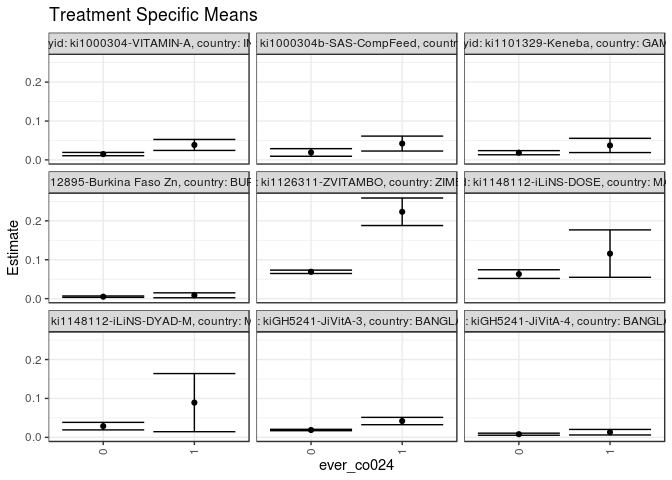

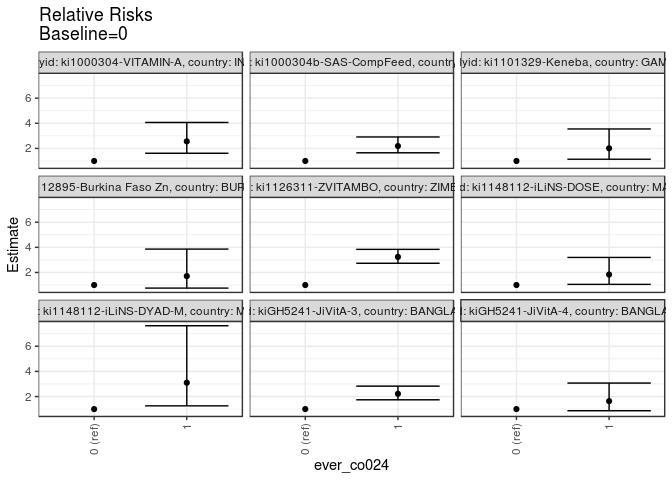

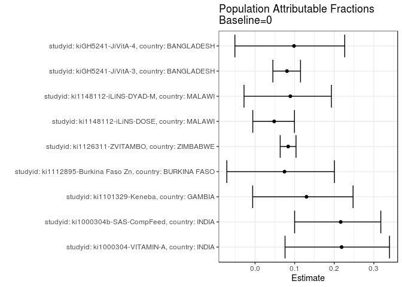

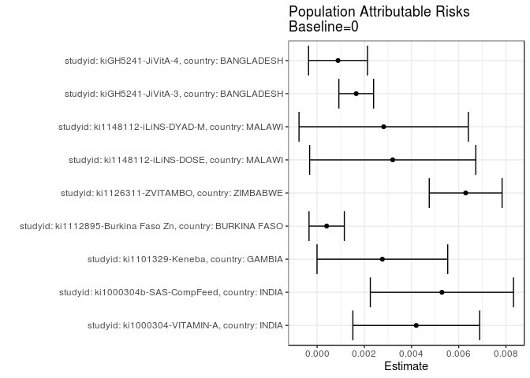

## Results Table

### Parameter: TSM

| studyid | country | intervention_level | baseline_level | estimate | ci_lower | ci_upper |
| --- | --- | --- | --- | --- | --- | --- |
| ki1000304-VITAMIN-A | INDIA | 0 | NA | 0.0150146 | 0.0107950 | 0.0192343 |
| ki1000304-VITAMIN-A | INDIA | 1 | NA | 0.0384761 | 0.0243846 | 0.0525676 |
| ki1000304b-SAS-CompFeed | INDIA | 0 | NA | 0.0191664 | 0.0093860 | 0.0289468 |
| ki1000304b-SAS-CompFeed | INDIA | 1 | NA | 0.0420340 | 0.0228648 | 0.0612032 |
| ki1101329-Keneba | GAMBIA | 0 | NA | 0.0185187 | 0.0132105 | 0.0238268 |
| ki1101329-Keneba | GAMBIA | 1 | NA | 0.0372154 | 0.0189363 | 0.0554946 |
| ki1112895-Burkina Faso Zn | BURKINA FASO | 0 | NA | 0.0050394 | 0.0032976 | 0.0067811 |
| ki1112895-Burkina Faso Zn | BURKINA FASO | 1 | NA | 0.0086101 | 0.0022588 | 0.0149613 |
| ki1126311-ZVITAMBO | ZIMBABWE | 0 | NA | 0.0689455 | 0.0646455 | 0.0732454 |
| ki1126311-ZVITAMBO | ZIMBABWE | 1 | NA | 0.2232800 | 0.1879185 | 0.2586414 |
| ki1148112-iLiNS-DOSE | MALAWI | 0 | NA | 0.0630835 | 0.0519255 | 0.0742415 |
| ki1148112-iLiNS-DOSE | MALAWI | 1 | NA | 0.1157370 | 0.0548540 | 0.1766200 |
| ki1148112-iLiNS-DYAD-M | MALAWI | 0 | NA | 0.0288210 | 0.0191264 | 0.0385156 |
| ki1148112-iLiNS-DYAD-M | MALAWI | 1 | NA | 0.0892857 | 0.0145691 | 0.1640023 |
| kiGH5241-JiVitA-3 | BANGLADESH | 0 | NA | 0.0189194 | 0.0171952 | 0.0206437 |
| kiGH5241-JiVitA-3 | BANGLADESH | 1 | NA | 0.0419498 | 0.0324952 | 0.0514045 |
| kiGH5241-JiVitA-4 | BANGLADESH | 0 | NA | 0.0081185 | 0.0054165 | 0.0108205 |
| kiGH5241-JiVitA-4 | BANGLADESH | 1 | NA | 0.0132665 | 0.0061406 | 0.0203925 |

### Parameter: E(Y)

| studyid | country | intervention_level | baseline_level | estimate | ci_lower | ci_upper |
| --- | --- | --- | --- | --- | --- | --- |
| ki1000304-VITAMIN-A | INDIA | NA | NA | 0.0192160 | 0.0149085 | 0.0235235 |
| ki1000304b-SAS-CompFeed | INDIA | NA | NA | 0.0244547 | 0.0133604 | 0.0355490 |
| ki1101329-Keneba | GAMBIA | NA | NA | 0.0212839 | 0.0160418 | 0.0265260 |
| ki1112895-Burkina Faso Zn | BURKINA FASO | NA | NA | 0.0054446 | 0.0037404 | 0.0071489 |
| ki1126311-ZVITAMBO | ZIMBABWE | NA | NA | 0.0752403 | 0.0708616 | 0.0796189 |
| ki1148112-iLiNS-DOSE | MALAWI | NA | NA | 0.0662869 | 0.0551877 | 0.0773861 |
| ki1148112-iLiNS-DYAD-M | MALAWI | NA | NA | 0.0316403 | 0.0217366 | 0.0415440 |
| kiGH5241-JiVitA-3 | BANGLADESH | NA | NA | 0.0205772 | 0.0188498 | 0.0223046 |
| kiGH5241-JiVitA-4 | BANGLADESH | NA | NA | 0.0090040 | 0.0064549 | 0.0115532 |

### Parameter: RR

| studyid | country | intervention_level | baseline_level | estimate | ci_lower | ci_upper |
| --- | --- | --- | --- | --- | --- | --- |
| ki1000304-VITAMIN-A | INDIA | 0 | 0 | 1.000000 | 1.0000000 | 1.000000 |
| ki1000304-VITAMIN-A | INDIA | 1 | 0 | 2.562576 | 1.6148628 | 4.066472 |
| ki1000304b-SAS-CompFeed | INDIA | 0 | 0 | 1.000000 | 1.0000000 | 1.000000 |
| ki1000304b-SAS-CompFeed | INDIA | 1 | 0 | 2.193108 | 1.6518022 | 2.911804 |
| ki1101329-Keneba | GAMBIA | 0 | 0 | 1.000000 | 1.0000000 | 1.000000 |
| ki1101329-Keneba | GAMBIA | 1 | 0 | 2.009615 | 1.1378736 | 3.549208 |
| ki1112895-Burkina Faso Zn | BURKINA FASO | 0 | 0 | 1.000000 | 1.0000000 | 1.000000 |
| ki1112895-Burkina Faso Zn | BURKINA FASO | 1 | 0 | 1.708564 | 0.7565733 | 3.858438 |
| ki1126311-ZVITAMBO | ZIMBABWE | 0 | 0 | 1.000000 | 1.0000000 | 1.000000 |
| ki1126311-ZVITAMBO | ZIMBABWE | 1 | 0 | 3.238500 | 2.7321879 | 3.838640 |
| ki1148112-iLiNS-DOSE | MALAWI | 0 | 0 | 1.000000 | 1.0000000 | 1.000000 |
| ki1148112-iLiNS-DOSE | MALAWI | 1 | 0 | 1.834664 | 1.0533999 | 3.195359 |
| ki1148112-iLiNS-DYAD-M | MALAWI | 0 | 0 | 1.000000 | 1.0000000 | 1.000000 |
| ki1148112-iLiNS-DYAD-M | MALAWI | 1 | 0 | 3.097944 | 1.2571385 | 7.634207 |
| kiGH5241-JiVitA-3 | BANGLADESH | 0 | 0 | 1.000000 | 1.0000000 | 1.000000 |
| kiGH5241-JiVitA-3 | BANGLADESH | 1 | 0 | 2.217289 | 1.7390301 | 2.827075 |
| kiGH5241-JiVitA-4 | BANGLADESH | 0 | 0 | 1.000000 | 1.0000000 | 1.000000 |
| kiGH5241-JiVitA-4 | BANGLADESH | 1 | 0 | 1.634115 | 0.8697510 | 3.070225 |

### Parameter: PAR

| studyid | country | intervention_level | baseline_level | estimate | ci_lower | ci_upper |
| --- | --- | --- | --- | --- | --- | --- |
| ki1000304-VITAMIN-A | INDIA | 0 | NA | 0.0042014 | 0.0015147 | 0.0068881 |
| ki1000304b-SAS-CompFeed | INDIA | 0 | NA | 0.0052883 | 0.0022546 | 0.0083221 |
| ki1101329-Keneba | GAMBIA | 0 | NA | 0.0027652 | -0.0000041 | 0.0055346 |
| ki1112895-Burkina Faso Zn | BURKINA FASO | 0 | NA | 0.0004053 | -0.0003427 | 0.0011532 |
| ki1126311-ZVITAMBO | ZIMBABWE | 0 | NA | 0.0062948 | 0.0047513 | 0.0078383 |
| ki1148112-iLiNS-DOSE | MALAWI | 0 | NA | 0.0032034 | -0.0003171 | 0.0067239 |
| ki1148112-iLiNS-DYAD-M | MALAWI | 0 | NA | 0.0028193 | -0.0007670 | 0.0064057 |
| kiGH5241-JiVitA-3 | BANGLADESH | 0 | NA | 0.0016578 | 0.0009218 | 0.0023938 |
| kiGH5241-JiVitA-4 | BANGLADESH | 0 | NA | 0.0008856 | -0.0003629 | 0.0021340 |

### Parameter: PAF

| studyid | country | intervention_level | baseline_level | estimate | ci_lower | ci_upper |
| --- | --- | --- | --- | --- | --- | --- |
| ki1000304-VITAMIN-A | INDIA | 0 | NA | 0.2186392 | 0.0756919 | 0.3394793 |
| ki1000304b-SAS-CompFeed | INDIA | 0 | NA | 0.2162498 | 0.0998997 | 0.3175600 |
| ki1101329-Keneba | GAMBIA | 0 | NA | 0.1299202 | -0.0060177 | 0.2474895 |
| ki1112895-Burkina Faso Zn | BURKINA FASO | 0 | NA | 0.0744357 | -0.0713715 | 0.2003994 |
| ki1126311-ZVITAMBO | ZIMBABWE | 0 | NA | 0.0836626 | 0.0634619 | 0.1034277 |
| ki1148112-iLiNS-DOSE | MALAWI | 0 | NA | 0.0483262 | -0.0057289 | 0.0994759 |
| ki1148112-iLiNS-DYAD-M | MALAWI | 0 | NA | 0.0891060 | -0.0278942 | 0.1927885 |
| kiGH5241-JiVitA-3 | BANGLADESH | 0 | NA | 0.0805638 | 0.0449661 | 0.1148347 |
| kiGH5241-JiVitA-4 | BANGLADESH | 0 | NA | 0.0983504 | -0.0509399 | 0.2264334 |